# Donors choose data analysis

#### 3. Vectorizing teacher_number_of_previously_posted_projects

```python
# Standardizing the teacher_number_of_previously_posted_projects data using StandardScaler(Uses mean and std for standardization)
previouslyPostedScaler = MinMaxScaler();
previouslyPostedScaler.fit(trainingData['teacher_number_of_previously_posted_projects'].values.reshape(-1, 1));
previouslyPostedStandardized = previouslyPostedScaler.transform(trainingData['teacher_number_of_previously_posted_projects'].values.reshape(-1, 1));
```

```python
print("Shape of standardized matrix of teacher_number_of_previously_posted_projects: ", previouslyPostedStandardized.shape);
equalsBorder(70);
print("Sample original number of previously posted projects: ");
equalsBorder(70);
print(trainingData['teacher_number_of_previously_posted_projects'].values[0:5]);
print("Sample standardized teacher_number_of_previously_posted_projects: ");
equalsBorder(70);
print(previouslyPostedStandardized[0:5]);
```

```
Shape of standardized matrix of teacher_number_of_previously_posted_projects:  (53529, 1)
======================================================================
Sample original number of previously posted projects:
======================================================================
[ 1  9 25  0  0]
Sample standardized teacher_number_of_previously_posted_projects:
======================================================================
[[0.00221729]
 [0.01995565]
 [0.05543237]
 [0.        ]
 [0.        ]]
```

#### 4. Vectorizing number_of_words_in_title

```python
numberOfWordsInTitleScaler = MinMaxScaler();
numberOfWordsInTitleScaler.fit(trainingData['number_of_words_in_title'].values.reshape(-1, 1));
numberOfWordsInTitleStandardized = numberOfWordsInTitleScaler.transform(trainingData['number_of_words_in_title'].values.reshape(-1, 1));
```

```python
print("Shape of standardized matrix of number_of_words_in_title: ", numberOfWordsInTitleStandardized.shape);
equalsBorder(70);
print("Sample original number of words in title: ");
equalsBorder(70);
print(trainingData['number_of_words_in_title'].values[0:5]);
print("Sample standardized number_of_words_in_title: ");
equalsBorder(70);
print(numberOfWordsInTitleStandardized[0:5]);
```

```
Shape of standardized matrix of number_of_words_in_title:  (53529, 1)
======================================================================
Sample original number of words in title:
======================================================================
[2 4 2 4 3]
Sample standardized number_of_words_in_title:
======================================================================
[[0.18181818]
 [0.36363636]
 [0.18181818]
 [0.36363636]
 [0.27272727]]
```

#### 5. Vectorizing number_of_words_in_essay

```python
numberOfWordsInEssayScaler = MinMaxScaler();
numberOfWordsInEssayScaler.fit(trainingData['number_of_words_in_essay'].values.reshape(-1, 1));
numberOfWordsInEssayStandardized = numberOfWordsInEssayScaler.transform(trainingData['number_of_words_in_essay'].values.reshape(-1, 1));
```

```python
print("Shape of standardized matrix of number_of_words_in_essay: ", numberOfWordsInEssayStandardized.shape);
equalsBorder(70);
print("Sample original number of words in essay: ");
equalsBorder(70);
print(trainingData['number_of_words_in_essay'].values[0:5]);
print("Sample standardized number_of_words_in_essay: ");
equalsBorder(70);
print(numberOfWordsInEssayStandardized[0:5]);
```

```
Shape of standardized matrix of number_of_words_in_essay:  (53529, 1)
======================================================================
Sample original number of words in essay:
======================================================================
[167 139 210  97 117]
Sample standardized number_of_words_in_essay:
======================================================================
[[0.39917695]
 [0.28395062]
 [0.57613169]
 [0.11111111]
 [0.19341564]]
```

```python
numberOfPoints = previouslyPostedStandardized.shape[0];
# Categorical data
categoriesVectorsSub = categoriesVectors[0:numberOfPoints];
subCategoriesVectorsSub = subCategoriesVectors[0:numberOfPoints];
teacherPrefixVectorsSub = teacherPrefixVectors[0:numberOfPoints];
schoolStateVectorsSub = schoolStateVectors[0:numberOfPoints];
projectGradeVectorsSub = projectGradeVectors[0:numberOfPoints];

# Text data
tfIdfEssayModelSub = tfIdfEssayModel[0:numberOfPoints];

# Numerical data
priceStandardizedSub = priceStandardized[0:numberOfPoints];
quantityStandardizedSub = quantityStandardized[0:numberOfPoints];
previouslyPostedStandardizedSub = previouslyPostedStandardized[0:numberOfPoints];
numberOfWordsInTitleStandardizedSub = numberOfWordsInTitleStandardized[0:numberOfPoints];
numberOfWordsInEssayStandardizedSub = numberOfWordsInEssayStandardized[0:numberOfPoints];
positiveSentimentScoreSub = trainingData['positive_sentiment_score'].values[0:numberOfPoints].reshape(-1, 1);
negativeSentimentScoreSub = trainingData['negative_sentiment_score'].values[0:numberOfPoints].reshape(-1, 1);
neutralSentimentScoreSub = trainingData['neutral_sentiment_score'].values[0:numberOfPoints].reshape(-1, 1);
compoundSentimentScoreSub = trainingData['compound_sentiment_score'].values[0:numberOfPoints].reshape(-1, 1);

# Classes
classesTrainingSub = classesTraining;
```

```python
supportVectorMachineResultsDataFrame = pd.DataFrame(columns =  ['Vectorizer', 'Model', 'Hyper Parameter - alpha', 'AUC', 'Data']);
supportVectorMachineResultsDataFrame
```

|  | Vectorizer | Model | Hyper Parameter - alpha | AUC | Data |
| --- | --- | --- | --- | --- | --- |

### Preparing cross validate data for analysis

```python
# Test data categorical features transformation
categoriesTransformedCrossValidateData = subjectsCategoriesVectorizer.transform(crossValidateData['cleaned_categories']);
subCategoriesTransformedCrossValidateData = subjectsSubCategoriesVectorizer.transform(crossValidateData['cleaned_sub_categories']);
teacherPrefixTransformedCrossValidateData = teacherPrefixVectorizer.transform(crossValidateData['teacher_prefix']);
schoolStateTransformedCrossValidateData = schoolStateVectorizer.transform(crossValidateData['school_state']);
projectGradeTransformedCrossValidateData = projectGradeVectorizer.transform(crossValidateData['project_grade_category']);

# Test data text features transformation
preProcessedEssaysTemp = preProcessingWithAndWithoutStopWords(crossValidateData['project_essay'])[1];
tfIdfEssayTransformedCrossValidateData = tfIdfEssayVectorizer.transform(preProcessedEssaysTemp);

# Test data numerical features transformation
priceTransformedCrossValidateData = priceScaler.transform(crossValidateData['price'].values.reshape(-1, 1));
quantityTransformedCrossValidateData = quantityScaler.transform(crossValidateData['quantity'].values.reshape(-1, 1));
previouslyPostedTransformedCrossValidateData = previouslyPostedScaler.transform(crossValidateData['teacher_number_of_previously_posted_projects'].values.reshape(-1, 1));
numberOfWordsInTitleTransformedCrossValidateData = numberOfWordsInTitleScaler.transform(crossValidateData['number_of_words_in_title'].values.reshape(-1, 1));
numberOfWordsInEssayTransformedCrossValidateData = numberOfWordsInEssayScaler.transform(crossValidateData['number_of_words_in_essay'].values.reshape(-1, 1));
positiveSentimentScoreCrossValidateData = crossValidateData['positive_sentiment_score'].values.reshape(-1, 1);
negativeSentimentScoreCrossValidateData = crossValidateData['negative_sentiment_score'].values.reshape(-1, 1);
neutralSentimentScoreCrossValidateData = crossValidateData['neutral_sentiment_score'].values.reshape(-1, 1);
compoundSentimentScoreCrossValidateData = crossValidateData['compound_sentiment_score'].values.reshape(-1, 1);
```

### Preparing Test data for analysis

```python
# Test data categorical features transformation
categoriesTransformedTestData = subjectsCategoriesVectorizer.transform(testData['cleaned_categories']);
subCategoriesTransformedTestData = subjectsSubCategoriesVectorizer.transform(testData['cleaned_sub_categories']);
teacherPrefixTransformedTestData = teacherPrefixVectorizer.transform(testData['teacher_prefix']);
schoolStateTransformedTestData = schoolStateVectorizer.transform(testData['school_state']);
projectGradeTransformedTestData = projectGradeVectorizer.transform(testData['project_grade_category']);

# Test data text features transformation
preProcessedEssaysTemp = preProcessingWithAndWithoutStopWords(testData['project_essay'])[1];
tfIdfEssayTransformedTestData = tfIdfEssayVectorizer.transform(preProcessedEssaysTemp);


# Test data numerical features transformation
priceTransformedTestData = priceScaler.transform(testData['price'].values.reshape(-1, 1));
quantityTransformedTestData = quantityScaler.transform(testData['quantity'].values.reshape(-1, 1));
previouslyPostedTransformedTestData = previouslyPostedScaler.transform(testData['teacher_number_of_previously_posted_projects'].values.reshape(-1, 1));
numberOfWordsInTitleTransformedTestData = numberOfWordsInTitleScaler.transform(testData['number_of_words_in_title'].values.reshape(-1, 1));
numberOfWordsInEssayTransformedTestData = numberOfWordsInEssayScaler.transform(testData['number_of_words_in_essay'].values.reshape(-1, 1));
positiveSentimentScoreTestData = testData['positive_sentiment_score'].values.reshape(-1, 1);
negativeSentimentScoreTestData = testData['negative_sentiment_score'].values.reshape(-1, 1);
neutralSentimentScoreTestData = testData['neutral_sentiment_score'].values.reshape(-1, 1);
compoundSentimentScoreTestData = testData['compound_sentiment_score'].values.reshape(-1, 1);
```

### Finding appropriate dimensions(less) using elbow method

```python
trainingMergedData = hstack((categoriesVectorsSub,\
                             subCategoriesVectorsSub,\
                             teacherPrefixVectorsSub,\
                             schoolStateVectorsSub,\
                             projectGradeVectorsSub,\
                             priceStandardizedSub,\
                             previouslyPostedStandardizedSub,\
                             numberOfWordsInTitleStandardizedSub,\
                             numberOfWordsInEssayStandardizedSub,\
                             positiveSentimentScoreSub,\
                             negativeSentimentScoreSub,\
                             neutralSentimentScoreSub,\
                             compoundSentimentScoreSub, \
                            tfIdfEssayModelSub));
svd = TruncatedSVD(n_components = trainingMergedData.shape[1] - 1, random_state = 42);
svd.fit(trainingMergedData);

componentsRatio = svd.explained_variance_ratio_;
```

```
[0.01792355 0.10202375 0.17900866 ... 1.         1.         1.        ]
```

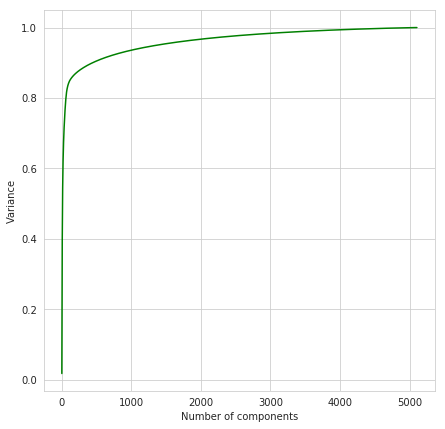

```python
components = np.arange(1, trainingMergedData.shape[1]);
componentsRatio =svd.explained_variance_ratio_.cumsum()

print(componentsRatio);

plt.xlabel('Number of components');
plt.ylabel('Variance');
plt.plot(components, componentsRatio, color = 'green');
```

### Observations:

1. As you can see from above plot that with dimensions more than 450 90% of variance is retained. So the less number of dimensions to start with inorder to get good results would be 450.
2. At dimensions more than 1400 more than 95% of variance is retained.

### Classification using data with reduced dimensions by support vector machine

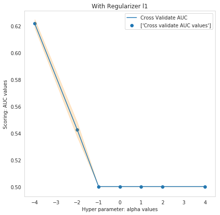

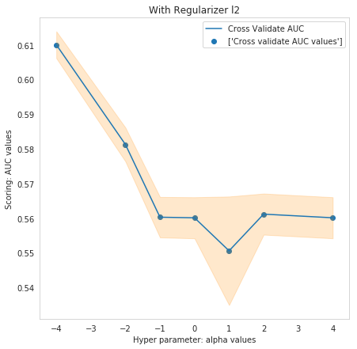

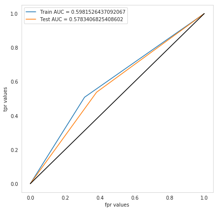

```
Results of analysis using data of dimensions 450 using support vector machine classifier:
========================================
Optimal Alpha value:  0.0001
========================================
Optimal Regularizer:  l1
========================================
AUC value of test data:  0.5783406825408602
========================================
Confusion Matrix :
============================================================
```

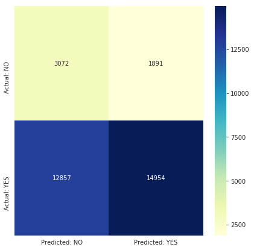

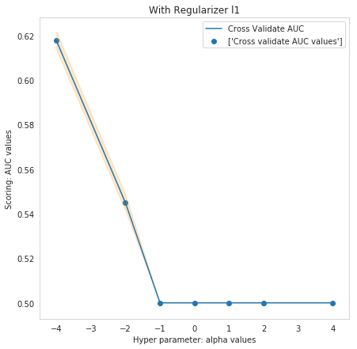

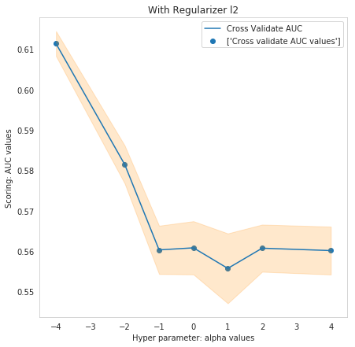

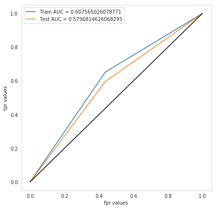

```
Results of analysis using data of dimensions 600 using support vector machine classifier:
========================================
Optimal Alpha value:  0.0001
========================================
Optimal Regularizer:  l1
========================================
AUC value of test data:  0.5796814626068295
========================================
Confusion Matrix :
============================================================
```

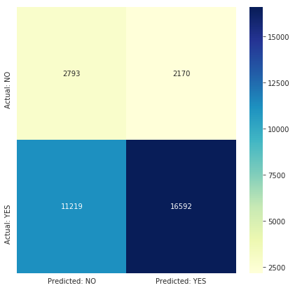

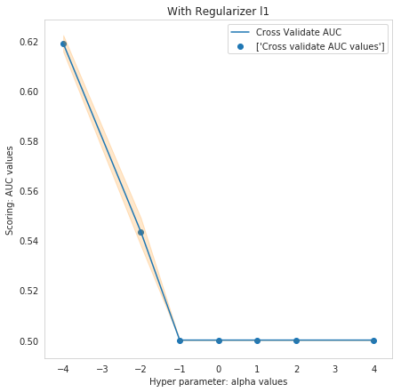

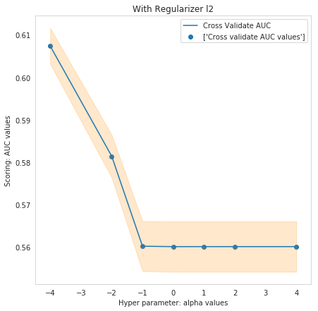

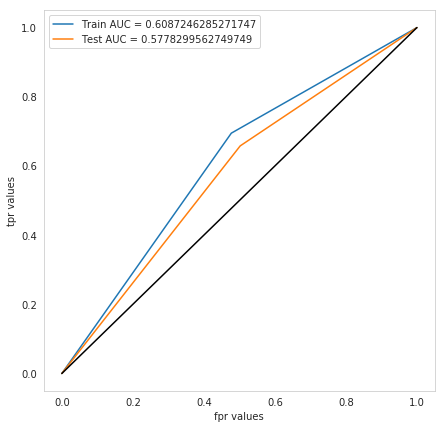

```
Results of analysis using data of dimensions 900 using support vector machine classifier:
========================================
Optimal Alpha value:  0.0001
========================================
Optimal Regularizer:  l1
========================================
AUC value of test data:  0.5778299562749749
========================================
Confusion Matrix :
============================================================
```

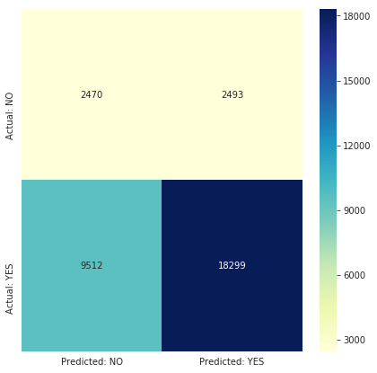

[8 more figures not shown]

```python
techniques = ['With Reduced Dimensions'];
n_componentsValues = [450, 600, 900, 1200, 1400];
for index, technique in enumerate(techniques):
  for n_components in n_componentsValues:
    trainingMergedData = hstack((categoriesVectorsSub,\
                             subCategoriesVectorsSub,\
                             teacherPrefixVectorsSub,\
                             schoolStateVectorsSub,\
                             projectGradeVectorsSub,\
                             priceStandardizedSub,\
                             previouslyPostedStandardizedSub,\
                             numberOfWordsInTitleStandardizedSub,\
                             numberOfWordsInEssayStandardizedSub,\
                             positiveSentimentScoreSub,\
                             negativeSentimentScoreSub,\
                             neutralSentimentScoreSub,\
                             compoundSentimentScoreSub,\
                             tfIdfEssayModelSub));
    svd = TruncatedSVD(n_components = n_components, random_state = 42);
    svd.fit(trainingMergedData);
    trainingMergedData = svd.transform(trainingMergedData);
    crossValidateMergedData = hstack((categoriesTransformedCrossValidateData,\
                                      subCategoriesTransformedCrossValidateData,\
                                      teacherPrefixTransformedCrossValidateData,\
                                      schoolStateTransformedCrossValidateData,\
                                      projectGradeTransformedCrossValidateData,\
                                      priceTransformedCrossValidateData,\
                                      previouslyPostedTransformedCrossValidateData,\
                                      numberOfWordsInTitleTransformedCrossValidateData,\
                                      numberOfWordsInEssayTransformedCrossValidateData,\
                                      positiveSentimentScoreCrossValidateData,\
                                      negativeSentimentScoreCrossValidateData,\
                                      neutralSentimentScoreCrossValidateData,\
                                      compoundSentimentScoreCrossValidateData,\
                                      tfIdfEssayTransformedCrossValidateData));
    crossValidateMergedData = svd.transform(crossValidateMergedData);

    testMergedData = hstack((categoriesTransformedTestData,\
                             subCategoriesTransformedTestData,\
                             teacherPrefixTransformedTestData,\
                             schoolStateTransformedTestData,\
                             projectGradeTransformedTestData,\
                             priceTransformedTestData,\
                             previouslyPostedTransformedTestData,\
                             numberOfWordsInTitleTransformedTestData,\
                             numberOfWordsInEssayTransformedTestData,\
                             positiveSentimentScoreTestData,\
                             negativeSentimentScoreTestData,\
                             neutralSentimentScoreTestData,\
                             compoundSentimentScoreTestData,\
                            tfIdfEssayTransformedTestData));
    testMergedData = svd.transform(testMergedData);

    svmClassifier = linear_model.SGDClassifier(loss = 'hinge', class_weight = 'balanced');
    tunedParameters = {'alpha': [0.0001, 0.01, 0.1, 1, 10, 100, 10000], 'penalty': ['l1', 'l2']};
    classifier = GridSearchCV(svmClassifier, tunedParameters, cv = 5, scoring = 'roc_auc');
    classifier.fit(trainingMergedData, classesTrainingSub);

    testScoresDataFrame = pd.DataFrame(data = np.hstack((classifier.cv_results_['param_alpha'].data[:, None], classifier.cv_results_['param_penalty'].data[:, None], classifier.cv_results_['mean_test_score'][:, None], classifier.cv_results_['std_test_score'][:, None])), columns = ['alpha', 'penalty', 'mts', 'stdts']);
    testScoresDataFrame

    crossValidateAucMeanValues = classifier.cv_results_['mean_test_score'];
    crossValidateAucStdValues = classifier.cv_results_['std_test_score'];

    testScoresDataFrame['logAlphaValues'] = [math.log10(x) for x in testScoresDataFrame['alpha']];

    plt.plot(testScoresDataFrame[testScoresDataFrame['penalty'] == 'l1']['logAlphaValues'], testScoresDataFrame[testScoresDataFrame['penalty'] == 'l1']['mts'], label = "Cross Validate AUC");
    plt.scatter(testScoresDataFrame[testScoresDataFrame['penalty'] == 'l1']['logAlphaValues'], testScoresDataFrame[testScoresDataFrame['penalty'] == 'l1']['mts'], label = ['Cross validate AUC values']);
    plt.gca().fill_between(testScoresDataFrame[testScoresDataFrame['penalty'] == 'l1']['logAlphaValues'].values, np.array(testScoresDataFrame[testScoresDataFrame['penalty'] == 'l1']['mts'].values - testScoresDataFrame[testScoresDataFrame['penalty'] == 'l1']['stdts'].values, dtype = float),\
                           np.array(testScoresDataFrame[testScoresDataFrame['penalty'] == 'l1']['mts'].values + testScoresDataFrame[testScoresDataFrame['penalty'] == 'l1']['stdts'].values, dtype = float), alpha = 0.2, color = 'darkorange');
    plt.xlabel('Hyper parameter: alpha values');
    plt.ylabel('Scoring: AUC values');
    plt.title("With Regularizer l1");
    plt.grid();
    plt.legend();
    plt.show();

    plt.plot(testScoresDataFrame[testScoresDataFrame['penalty'] == 'l2']['logAlphaValues'], testScoresDataFrame[testScoresDataFrame['penalty'] == 'l2']['mts'], label = "Cross Validate AUC");
    plt.scatter(testScoresDataFrame[testScoresDataFrame['penalty'] == 'l2']['logAlphaValues'], testScoresDataFrame[testScoresDataFrame['penalty'] == 'l2']['mts'], label = ['Cross validate AUC values']);
    plt.gca().fill_between(testScoresDataFrame[testScoresDataFrame['penalty'] == 'l2']['logAlphaValues'].values, np.array(testScoresDataFrame[testScoresDataFrame['penalty'] == 'l2']['mts'].values - testScoresDataFrame[testScoresDataFrame['penalty'] == 'l2']['stdts'].values, dtype = float),\
                           np.array(testScoresDataFrame[testScoresDataFrame['penalty'] == 'l2']['mts'].values + testScoresDataFrame[testScoresDataFrame['penalty'] == 'l2']['stdts'].values, dtype = float), alpha = 0.2, color = 'darkorange');
    plt.xlabel('Hyper parameter: alpha values');
    plt.ylabel('Scoring: AUC values');
    plt.title("With Regularizer l2");
    plt.grid();
    plt.legend();

    plt.show();

    optimalHypParamValue = classifier.best_params_['alpha'];
    optimalHypParam2Value = classifier.best_params_['penalty'];
    svmClassifier = linear_model.SGDClassifier(loss = 'hinge', class_weight = 'balanced', alpha = optimalHypParamValue, penalty = optimalHypParam2Value);
    svmClassifier.fit(trainingMergedData, classesTrainingSub);
    predScoresTraining = svmClassifier.predict(trainingMergedData);
    fprTrain, tprTrain, thresholdTrain = roc_curve(classesTraining, predScoresTraining);
    predScoresTest = svmClassifier.predict(testMergedData);
    fprTest, tprTest, thresholdTest = roc_curve(classesTest, predScoresTest);

    plt.plot(fprTrain, tprTrain, label = "Train AUC = " + str(auc(fprTrain, tprTrain)));
    plt.plot(fprTest, tprTest, label = "Test AUC = " + str(auc(fprTest, tprTest)));
    plt.plot([0, 1], [0, 1], 'k-');
    plt.xlabel("fpr values");
    plt.ylabel("tpr values");
    plt.grid();
    plt.legend();
    plt.show();

    areaUnderRocValueTest = auc(fprTest, tprTest);

    print("Results of analysis using data of dimensions {} using support vector machine classifier: ".format(n_components));
    equalsBorder(40);
    print("Optimal Alpha value: ", optimalHypParamValue);
    equalsBorder(40);
    print("Optimal Regularizer: ", optimalHypParam2Value);
    equalsBorder(40);
    print("AUC value of test data: ", str(areaUnderRocValueTest));
    # Predicting classes of test data projects
    predictionClassesTest = svmClassifier.predict(testMergedData);
    equalsBorder(40);
    # Printing confusion matrix
    confusionMatrix = confusion_matrix(classesTest, predictionClassesTest);
    # Creating dataframe for generated confusion matrix
    confusionMatrixDataFrame = pd.DataFrame(data = confusionMatrix, index = ['Actual: NO', 'Actual: YES'], columns = ['Predicted: NO', 'Predicted: YES']);
    print("Confusion Matrix : ");
    equalsBorder(60);
    sbrn.heatmap(confusionMatrixDataFrame, annot = True, fmt = 'd', cmap="YlGnBu");
    plt.show();
    # Adding results to results dataframe
    supportVectorMachineResultsDataFrame = supportVectorMachineResultsDataFrame.append({'Vectorizer': technique, 'Model': 'SVM(SGD - hinge loss)', 'Hyper Parameter - alpha': optimalHypParamValue, 'AUC': areaUnderRocValueTest}, ignore_index = True);
```

### Summary of results of above classification using support vector machine

```python
supportVectorMachineResultsDataFrame
```

[output not shown]

### Conclusions of above analysis

1. From above analysis it seems that when data is balanced and text features are vectorized using bag of words the support vector machine is giving best results with auc value of 0.6614. The classification of negative points into negative points are also reasonable with this model but with other models it is kind of biased.
2. When classification is done using imbalanced data with reduced dimensions it is giving less auc values and a biased model(dumb model) that is classifying points incorrectly.
3. At last the good combination would be using balanced data with all categorical features, numerical features and text features vectorized with bag of words technique and hyper parameter value as 0.01.